# scNMT_transcriptome Help

Aaron Doe

11/19/2019

## Help Page

### Setting up Snakemake

The first step to setting up this pipeline is to link your samples. To do this, make a samples directory in your working directory. Then, in that samples directory create a directory called “raw”. You can then symlink your raw fastqs file into this directory.

```bash
ln -s /path/to/fastqs/* samples/raw/
```

This will create a symlink for each FASTQ file located in the samples/raw directory. Make sure your symlinks follow the naming conventions in the Snakefile:

"samples/raw/{sample}_R1.fq.gz"

You should then run a snakemake dry run to ensure there are no errors and that all of your samples will be processed.

```bash
snakemake -np --verbose
```

### Alignment Rule Outputs

#### Trimming

The first rule is trimming which outputs trimmed samples, a trimming report which summarizes how the trimming went, as well as an html outputted from FastQC.

For more information on FastQC and how to interpret its output go to, https://www.bioinformatics.babraham.ac.uk/projects/fastqc/

#### FastQ Screen

FastQ Screen screens your reads against known databases to ensure that the composition of your sample matches what you would expect. It will screen against multiple organisms as well as for things like rRNA and will tell you the percentage of hits in each.

#### HISAT2

HISAT2 is used to align the paired-end reads. HISAT2 outputs a SAM file by default, so there is a second step in this rule to convert that SAM file to a BAM file and then delete the SAM file. You are left with one BAM file per cell containing the mapped reads by cell. In the config file you need to specify the path to the HISAT index, the path to the HISAT tool itself, and the path to the necessary GTF file.

#### FeatureCounts

FeatureCounts takes all of the BAM files outputted in the previous step and outputs one counts table. It will also output a counts summary table which tells for each cell how many reads were aligned and misaligned. For those that are misaligned, it splits them into categories of why they were unaligned.

#### FilterCounts

FilterCounts is a custom script that filters the counts table for the biotype you specify in the config file (most commonly protein-coding genes). It will also output two metadata files, one for the samples and one for the genes. The sample metadata file simply lists the BAM file and the cell associated with the BAM file. The gene metadata file tells the chromosome position and strand for every gene in the counts table.

### Analysis Rule Outputs

#### Seurat

The analysis side of this pipeline has just one rule where it inputs the counts table into Seurat. The first thing Seurat does is output QC plots telling you the number of counts, features, and mitochondrial content in each cell. There are then a number of parameters that are drawn from the config file to filter the dataset based off of these QC values. It will then output the same QC plots again, this time with only the cells that pass QC present.

Another important pre-analysis step that Seurat takes it to regress out the effects of cell cycle. It then proceeds to go through all of the analysis twice, once with the cell cycle regressed dataset, and once with the original dataset. This allows the user to decide whether or not they want to use cell cycle regression. To make this decision it helps to look at the two UMAPs outputted. If in the original dataset UMAP the clusters seem to be separated primarily by cell cycle like so,

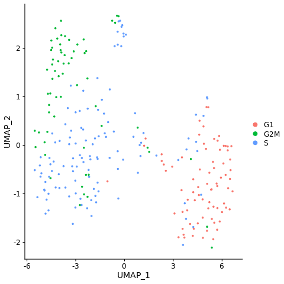

UMAP by Phase

then the user will probably want to use the cell cycle regressed version because we don’t want the clusters to be based only on cell cycle phase. However, many cell cycle genes have other functions, so if the original clusters are not being driven too heavily by cell cycle it is recommended to just stick to the orignial dataset so those other effects aren’t lost.

Seurat then gets into the analysis part of the rule. It first identifies the highly variable genes in the dataset and outputs them as a tsv and a scatter plots. Then, using the clusters it identifies, it outputs a list of genes that are differentially expressed between those clusters and outputs a heatmap showing the top markers for every cluster. Finally, it will output a Seurat object with all of this information embedded in it that will be used further downstream in the multiomics pipeline.